# Finding optimal weights for Neural Networks

## Back propagation versus Ramdomized optimization

## 1. Objective:

The purpose of this project is to find the optimal weights for Neural Network using Randomized Optimization and compare the perfromance against the perfromance of Neural Network with back propagation.

## 2. Datasets

### Wine Dataset

UCI Wine Quality dataset consists physicochemical and sensory data red and white variants of the Portuguese "Vinho Verde" wine. Dataset is available at https://archive.ics.uci.edu/ml/datasets/Wine+Quality

Number of Instances: red wine - 1599  
Number of Attributes: 11 + output attribute

Attribute Information Input variables (based on physicochemical tests): 1 - fixed acidity 2 - volatile acidity 3 - citric acid 4 - residual sugar 5 - chlorides 6 - free sulfur dioxide 7 - total sulfur dioxide 8 - density 9 - pH 10 - sulphates 11 - alcohol  
Output variable (based on sensory data): 12 - quality (score between 0 and 10)

## 3. Data Preprocessing

```python
#Packages Used
import pandas as pd
import numpy as np
import utils
import time
import mlrose
import matplotlib.pyplot as plt
import seaborn as sns
from sklearn import preprocessing
from sklearn.preprocessing import StandardScaler
from sklearn.model_selection import StratifiedKFold, train_test_split, cross_val_predict, cross_val_score, GridSearchCV
from sklearn.neural_network import MLPClassifier


from sklearn.model_selection import cross_val_score
from sklearn.metrics import classification_report
from sklearn.metrics import average_precision_score, precision_recall_curve
from sklearn.metrics import plot_precision_recall_curve

from sklearn.metrics import confusion_matrix
from sklearn.metrics import accuracy_score, precision_score, recall_score, f1_score
%matplotlib inline
```

```python
#load red wine dataset
dataset_loc_red = "./datasets/wine/winequality-red.csv"
df_red = pd.read_csv(dataset_loc_red, sep=";")

df_red.head()
```

|  | fixed acidity | volatile acidity | citric acid | residual sugar | chlorides | free sulfur dioxide | total sulfur dioxide | density | pH | sulphates | alcohol | quality |
| --- | --- | --- | --- | --- | --- | --- | --- | --- | --- | --- | --- | --- |
| 0 | 7.4 | 0.70 | 0.00 | 1.9 | 0.076 | 11.0 | 34.0 | 0.9978 | 3.51 | 0.56 | 9.4 | 5 |
| 1 | 7.8 | 0.88 | 0.00 | 2.6 | 0.098 | 25.0 | 67.0 | 0.9968 | 3.20 | 0.68 | 9.8 | 5 |
| 2 | 7.8 | 0.76 | 0.04 | 2.3 | 0.092 | 15.0 | 54.0 | 0.9970 | 3.26 | 0.65 | 9.8 | 5 |
| 3 | 11.2 | 0.28 | 0.56 | 1.9 | 0.075 | 17.0 | 60.0 | 0.9980 | 3.16 | 0.58 | 9.8 | 6 |
| 4 | 7.4 | 0.70 | 0.00 | 1.9 | 0.076 | 11.0 | 34.0 | 0.9978 | 3.51 | 0.56 | 9.4 | 5 |

```python
# Categorize wine into "above average" and "below average" wines
df_red["quality"].values[df_red["quality"] <= 5] = 0
df_red["quality"].values[df_red["quality"] > 5] = 1
```

```python
Wine_X = df_red.iloc[:,:-1]
Wine_y = df_red.iloc[:,-1]
```

```python
# Split the data into a training set and a test set
Wine_X_train, Wine_X_test, Wine_y_train, Wine_y_test = train_test_split(Wine_X, Wine_y, random_state=1, test_size=0.30)
```

```python
scaler = StandardScaler()
Wine_X_train = scaler.fit_transform(Wine_X_train)
Wine_X_test = scaler.transform(Wine_X_test)
model_stats=[]
cv=10
```

## 4. Neural Network with Back Propagation

### 4.1 Default Parameters

```
Confusion matrix, without normalization
[[387 127]
 [142 463]]
```

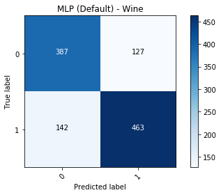

```python
Wine_mlpclf =  MLPClassifier(random_state=1)

Wine_y_pred = cross_val_predict(Wine_mlpclf, Wine_X_train, Wine_y_train, cv=cv, n_jobs=-1)

cnf_matrix = confusion_matrix(Wine_y_train, Wine_y_pred)
np.set_printoptions(precision=2)

# Plot non-normalized confusion matrix
plt.figure()
utils.plot_confusion_matrix(cnf_matrix, classes=[0,1],
                      title='MLP (Default) - Wine')
```

```python
modelid = "MLP (Default) - Wine"
prscore = precision_score(Wine_y_train, Wine_y_pred, average='binary')
rcscore = recall_score(Wine_y_train, Wine_y_pred, average='binary')
f1score = f1_score(Wine_y_train, Wine_y_pred, average='binary')

model_stats.append([modelid, prscore, rcscore, f1score])
print("Precision: "+str("{:.2f}".format(prscore))+", Recall: "+str("{:.2f}".format(rcscore))+", F1 Score: "+str("{:.2f}".format(f1score)))
```

```
Precision: 0.78, Recall: 0.77, F1 Score: 0.77
```

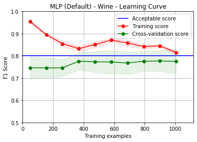

```python
#plot learning curve
utils.plot_learning_curve(Wine_mlpclf, "MLP (Default) - Wine - Learning Curve", Wine_X_train, Wine_y_train, cv=cv, n_jobs=-1, exp_score=0.8, train_sizes=np.linspace(0.05, 1.0, 10), ylim=[0.5,1])
```

### 4.2 Hyperparameter Tuning - Iteration 1

```python
h_units = [10, 20, 30, 40, 50, 60, 70, 80, 90]
learning_rates = np.arange(0.0, 0.005, 0.0005)
param_grid = {'hidden_layer_sizes': h_units, 'learning_rate_init': learning_rates}

Wine_mlpgs= GridSearchCV(Wine_mlpclf, param_grid, cv=cv, scoring='f1', n_jobs=-1)
Wine_mlpgs.fit(Wine_X_train,Wine_y_train)
```

```
GridSearchCV(cv=10, error_score=nan,
             estimator=MLPClassifier(activation='relu', alpha=0.0001,
                                     batch_size='auto', beta_1=0.9,
                                     beta_2=0.999, early_stopping=False,
                                     epsilon=1e-08, hidden_layer_sizes=(100,),
                                     learning_rate='constant',
                                     learning_rate_init=0.001, max_fun=15000,
                                     max_iter=200, momentum=0.9,
                                     n_iter_no_change=10,
                                     nesterovs_momentum=True, power_t=0.5,
                                     random_state=1, shuffle=True,
                                     solver='adam', tol=0.0001,
                                     validation_fraction=0.1, verbose=False,
                                     warm_start=False),
             iid='deprecated', n_jobs=-1,
             param_grid={'hidden_layer_sizes': [10, 20, 30, 40, 50, 60, 70, 80,
                                                90],
                         'learning_rate_init': array([0., 0., 0., 0., 0., 0., 0., 0., 0., 0.])},
             pre_dispatch='2*n_jobs', refit=True, return_train_score=False,
             scoring='f1', verbose=0)
```

```python
print("Best Score:" + str(Wine_mlpgs.best_score_))
print("Best Parameters: " + str(Wine_mlpgs.best_params_))
print("Best Estimator: " + str(Wine_mlpgs.best_estimator_))
```

```
Best Score:0.789023064681248
Best Parameters: {'hidden_layer_sizes': 30, 'learning_rate_init': 0.0035}
Best Estimator: MLPClassifier(activation='relu', alpha=0.0001, batch_size='auto', beta_1=0.9,
              beta_2=0.999, early_stopping=False, epsilon=1e-08,
              hidden_layer_sizes=30, learning_rate='constant',
              learning_rate_init=0.0035, max_fun=15000, max_iter=200,
              momentum=0.9, n_iter_no_change=10, nesterovs_momentum=True,
              power_t=0.5, random_state=1, shuffle=True, solver='adam',
              tol=0.0001, validation_fraction=0.1, verbose=False,
              warm_start=False)
```

```
Confusion matrix, without normalization
[[393 121]
 [132 473]]
```

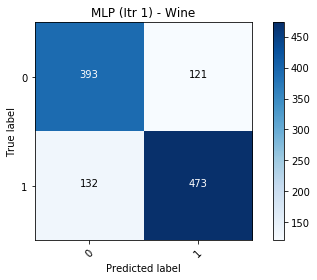

```python
Wine_mlpclf =  MLPClassifier(hidden_layer_sizes=Wine_mlpgs.best_params_["hidden_layer_sizes"], learning_rate_init=Wine_mlpgs.best_params_["learning_rate_init"], random_state=1)

Wine_y_pred = cross_val_predict(Wine_mlpclf, Wine_X_train, Wine_y_train, cv=cv, n_jobs=-1)

cnf_matrix = confusion_matrix(Wine_y_train, Wine_y_pred)
np.set_printoptions(precision=2)

# Plot non-normalized confusion matrix
plt.figure()
utils.plot_confusion_matrix(cnf_matrix, classes=[0,1],
                      title='MLP (Itr 1) - Wine')
```

```python
modelid = "MLP (Itr 1) - Wine"
prscore = precision_score(Wine_y_train, Wine_y_pred, average='binary')
rcscore = recall_score(Wine_y_train, Wine_y_pred, average='binary')
f1score = f1_score(Wine_y_train, Wine_y_pred, average='binary')

model_stats.append([modelid, prscore, rcscore, f1score])
print("Precision: "+str("{:.2f}".format(prscore))+", Recall: "+str("{:.2f}".format(rcscore))+", F1 Score: "+str("{:.2f}".format(f1score)))
```

```
Precision: 0.80, Recall: 0.78, F1 Score: 0.79
```

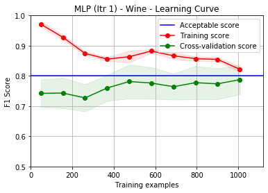

```python
#plot learning curve
utils.plot_learning_curve(Wine_mlpclf, "MLP (Itr 1) - Wine - Learning Curve", Wine_X_train, Wine_y_train, cv=cv, n_jobs=-1, exp_score=0.8, train_sizes=np.linspace(0.05, 1.0, 10), ylim=[0.5,1])
```